# 10.16 Intro to Data Science

## Time Series and Simple Linear Regression

Time series are **sequences of data points recorded over time**, often at regular intervals.  
We’ll use **simple linear regression** to explore and predict trends in time series data.

We’ll use time series to:

1. **Analyze** patterns in historical data.
2. **Forecast** future values using regression.

## What Is a Time Series?

A **time series** is a collection of observations recorded at successive points in time.

**Examples:**

- Daily closing stock prices
- Hourly temperature readings
- Changing positions of a plane in flight
- Annual crop yields
- Quarterly company profits

Each observation is associated with a **timestamp**.

## Univariate vs. Multivariate Time Series

- **Univariate:** One observation per time point  
  *Example:* Average January temperature per year in New York City.
- **Multivariate:** Two or more observations per time point  
  *Example:* Temperature, humidity, and barometric pressure recorded together.

## Common Time Series Tasks

1. **Time Series Analysis**
   - Looks for patterns, seasonality, and trends in past data.
   - Example: Monthly temperature variations across seasons.
2. **Time Series Forecasting**
   - Uses past data to **predict future values**.
   - Example: Predicting next year’s average January temperature.

## Visualizing Time Series Data

We’ll use:

- **pandas** for data handling
- **Seaborn** and **Matplotlib** for visualization

Start IPython with Matplotlib support:

```python
import matplotlib as mp
```

# Simple Linear Regression

### Understanding Linear Relationships with Real Data

We’ll use **Simple Linear Regression** to model and predict the relationship between:

- **Independent variable (x):** Year (time)
- **Dependent variable (y):** Average January high temperature in NYC

## What Is a Linear Relationship?

A **linear relationship** exists when one variable changes proportionally with another.

Example: Fahrenheit and Celsius temperatures are linearly related by

$$ C = \frac{5}{9} (F - 32) $$

Here:

- `F` = Fahrenheit temperature (independent variable)
- `C` = Celsius temperature (dependent variable)

```python
# Define the Fahrenheit to Celsius conversion as a lambda function
c = lambda f: 5 / 9 * (f - 32)

# Generate Fahrenheit values (0–100 °F) and their Celsius equivalents
temps = [(f, c(f)) for f in range(0, 101, 10)]
temps
```

```
[(0, -17.77777777777778),
 (10, -12.222222222222223),
 (20, -6.666666666666667),
 (30, -1.1111111111111112),
 (40, 4.444444444444445),
 (50, 10.0),
 (60, 15.555555555555557),
 (70, 21.11111111111111),
 (80, 26.666666666666668),
 (90, 32.22222222222222),
 (100, 37.77777777777778)]
```

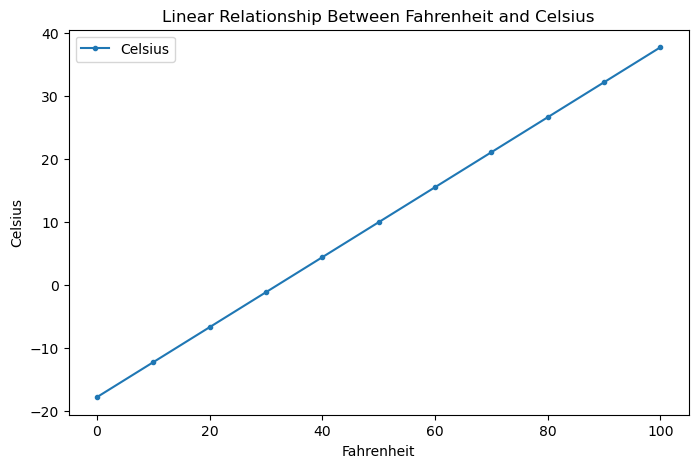

```python
import pandas as pd

# Create a DataFrame
temps_df = pd.DataFrame(temps, columns=['Fahrenheit', 'Celsius'])

# Plot the linear relationship
axes = temps_df.plot(x='Fahrenheit', y='Celsius', style='.-', figsize=(8, 5))
axes.set_ylabel('Celsius')
axes.set_title('Linear Relationship Between Fahrenheit and Celsius')
```

## Components of the Simple Linear Regression Equation

The equation of a straight line is:

$$ y = mx + b $$

Where:

- **m** → slope (rate of change)
- **b** → intercept (value when x = 0)
- **x** → independent variable
- **y** → dependent (predicted) variable

## How Simple Linear Regression Works

The algorithm finds the **best-fit line** through data points by adjusting `m` (slope) and `b` (intercept)  
to **minimize the total squared distance** between the points and the line — this is called  
**Ordinary Least Squares (OLS)**.

## Function: `linregress` from `scipy.stats`

The `linregress()` function automatically computes:

- `slope` (m)
- `intercept` (b)
- `r-value` (correlation coefficient)
- `p-value` (significance test)
- `std_err` (standard error of the estimate)

We’ll use these results to plot and interpret our regression line.

```python
# Import required libraries
import pandas as pd
import seaborn as sns
import matplotlib.pyplot as plt
from scipy.stats import linregress
```

## Step 1: Load the Temperature Data

We'll load a CSV file containing **average January high temperatures in NYC** (1895–2025). Each row contains:

- `Year`
- `Temperature (°F)`

[figure not shown]

```python
# Load dataset
df = pd.read_csv('nyc_january_avg_highs.csv', skiprows=2)

# Display the first few rows
df.head()
```

|  | Date | Value |
| --- | --- | --- |
| 0 | 189501 | 28.7 |
| 1 | 189601 | 27.6 |
| 2 | 189701 | 28.4 |
| 3 | 189801 | 33.0 |
| 4 | 189901 | 28.9 |

## Data Description

The dataset (`nyc_january_avg_highs.csv`) includes:

- **Date** → formatted as `YYYYMM`
- **Value** → average January temperature (°F)

The first two lines of the file are metadata and must be skipped when reading.

## Step 2: Prepare the Data

Rename columns for clarity and confirm that data types are appropriate.

```python
# Rename columns (if needed)
df.columns = ['Date', 'Temperature']

# Ensure correct data types
df.info()
```

```
<class 'pandas.core.frame.DataFrame'>
RangeIndex: 131 entries, 0 to 130
Data columns (total 2 columns):
 #   Column       Non-Null Count  Dtype
---  ------       --------------  -----
 0   Date         131 non-null    int64
 1   Temperature  131 non-null    float64
dtypes: float64(1), int64(1)
memory usage: 2.2 KB
```

```python
df.head()
```

|  | Date | Temperature |
| --- | --- | --- |
| 0 | 189501 | 28.7 |
| 1 | 189601 | 27.6 |
| 2 | 189701 | 28.4 |
| 3 | 189801 | 33.0 |
| 4 | 189901 | 28.9 |

```python
# Extract year from the 'Date' column (first 4 digits)
df["Year"] = df["Date"].astype(str).str[:4].astype(int)

# Drop the original 'Date' column
df = df[["Year", "Temperature"]]

# Display the first few rows
df.head()
```

|  | Year | Temperature |
| --- | --- | --- |
| 0 | 1895 | 28.7 |
| 1 | 1896 | 27.6 |
| 2 | 1897 | 28.4 |
| 3 | 1898 | 33.0 |
| 4 | 1899 | 28.9 |

## Step 3: Visualize the Data

We’ll plot the raw data points to visualize how the January average temperature has changed over time.

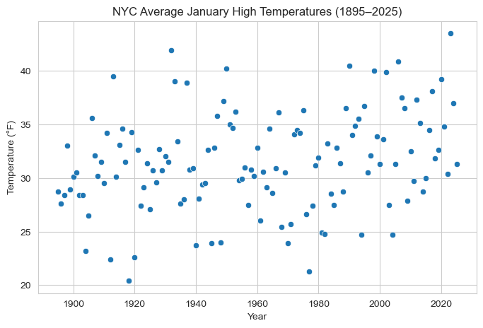

```python
sns.set_style("whitegrid")
plt.figure(figsize=(8,5))
sns.scatterplot(data=df, x="Year", y="Temperature")
plt.title("NYC Average January High Temperatures (1895–2025)")
plt.xlabel("Year")
plt.ylabel("Temperature (°F)")
plt.show()
```

## Step 4: Perform Linear Regression

We’ll use `linregress()` to find the **slope** and **intercept** of the best-fit line.

```python
# Perform regression
slope, intercept, r_value, p_value, std_err = linregress(df["Year"], df["Temperature"])

# Display results
print(f"Slope (m): {slope:.4f}")
print(f"Intercept (b): {intercept:.2f}")
print(f"R-squared: {r_value**2:.3f}")
```

```
Slope (m): 0.0321
Intercept (b): -31.39
R-squared: 0.071
```

## Step 5: Plot the Regression Line

We’ll use Seaborn’s `regplot` to display both the data and the fitted regression line.

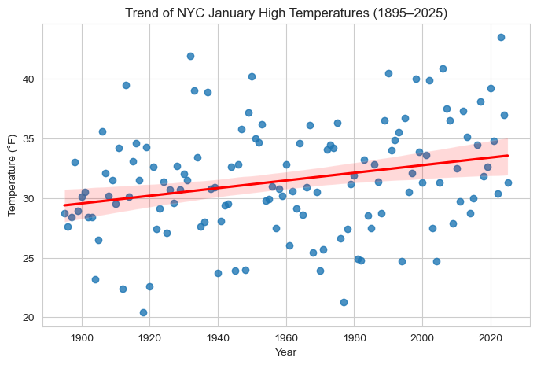

```python
plt.figure(figsize=(8,5))
sns.regplot(data=df, x="Year", y="Temperature", line_kws={"color":"red"})
plt.title("Trend of NYC January High Temperatures (1895–2025)")
plt.xlabel("Year")
plt.ylabel("Temperature (°F)")
plt.show()
```

## Step 6: Make Predictions

We can now use our regression equation to **predict** temperatures for future or past years.

```python
# Predict January high temperature for 2026
year = 2026
predicted_temp = slope * year + intercept
print(f"Predicted January Avg High in {year}: {predicted_temp:.2f} °F")
```

```
Predicted January Avg High in 2026: 33.59 °F
```

# Descriptive Statistics for the Dataset

Before performing regression, it’s helpful to explore **basic descriptive statistics** for the temperature data.

We can use **pandas** to quickly summarize:

- Number of data points
- Mean (average temperature)
- Standard deviation (data spread)
- Minimum and maximum values
- Quartiles (25%, 50%, 75%)

```python
# Set display precision for readability
pd.set_option('display.precision', 2)

# Display descriptive statistics for the Temperature column
df['Temperature'].describe()
```

```
count    131.00
mean      31.48
std        4.58
min       20.40
25%       28.55
50%       31.30
75%       34.50
max       43.50
Name: Temperature, dtype: float64
```

## Summary

- Used `linregress()` for **simple linear regression**
- Visualized temperature data using **Seaborn**
- Predicted future temperatures using the regression equation

This demonstrates how **time series forecasting** can begin with simple regression models before progressing to more advanced methods like **machine learning** and **deep learning (RNNs)**.